# Untitled

WHSP

14 de dezembro de 2018

## Integrando R com QGIS

RQGIS: Integrating R with QGIS for Statistical Geocomputing https://rjournal.github.io/archive/2017/RJ-2017-067/RJ-2017-067.pdf

### Introdução

Se definimos um SIG como um sistema que captura, armazena, manipula, analiza, gerencia e apresenta dados geográficos ou espaciais (ou seja que tem um atributo que os relaciona com o espaço), poderiamos dizer, sem temor a errar que o *R* como ecosistema de análise, tem se tornado um deles.

Muitos pacotes contribuiram para iss0, fornecendo classes espaciais e algoritmos de análise (veja por exemplo, `maptools`, `raster`, `sp`, `rgeos`, `rgdal` e `sf`, dentre outros) ou ainda fornecendo conexão com SIG como *GRASS* (`rArcInfo`, `rgrass7`). Apesar disso, *R* ainda carecia de capacidade de processamento em muitas operações típicas dos SIG, como por exemplo calcular o índice de vegetação ou fazer uma classificação por curvatura. O que estava faltando era uma interfase que permitisse ao *R* acessar a um dos mais usados SIG de código aberto em uso: o QGIS.

**RQGIS** (para versões 2.X do QGIS) e **RQGIS3** (para 3.X) vem para oferecer essa facilidade e permitir executar operações típicas de SIG no ambiente *R*. Esclarecendo que ao dia de hoje, enquanto o pacote **RQGIS** esta disponivel no repositorio do CRAN, o **RQGIS3** tem de ser instalado a partir da pagina de um dos autores, em https://github.com/jannes-m/RQGIS3.Este documento se va a referir especificamente a la version 2 de QGIS, mas as funcoes e procedimentos sao identicos para a versao 3.

O QGIS permite executar scripts em *R* através da caixa de ferramentas, o que facilita o uso para as pessoas que não querem usá-lo diretamente, mas o acesso às capacidades do QGIS dentro do R tem a vantagem de tornar disponível outras ferramentas de SIG que o próprio QGIS tem, como SAGA, GRASS, TauDem, Lidar, etc.

### Conceitos básicos do pacote

- **RQGIS** faz uso da API Python QGIS para acessar os módulos do QGIS
- para conseguir o acesso em primeiro lugar define todas as variáveis de ambiente necessárias e depois estabelece a conexão com o Python, usando o pacote `reticulate`
- **RQGIS** tem dois componentes principais: um código Python que define a classe Python “RQGIS”, incluindo os seus métodos, e
- um arquivo *R* que estabelece a interfase com Python QGIS e permite executar o QGIS dentro do *R*.
- As principais funções do **RQGIS** são:

  1- `open_app()`, que estabelece a conexão com Python QGIS

  2- `find_algoritms()`, para procurar as nomes dos geoalgoritmos;

  3- `get_args_man()`, para recuperar os parâmetros de processamento dos algoritmos, e

  4- `run_qgis()`, que chama os algoritmos presentes no QGIS e permite que objetos `sf`, `raster`e `sp` sejam argumentos no processamento e as saídas sejam carregadas no *R*.

### Uso do RQGIS

Como o pacote e uma interfase entre o *R* e o QGIS, vamos supor que este ja foi previamente instalado, senao faca a instalacao a partir do repositorio oficial do QGIS, escolhendo a versao do seu sistema operativo adequada e seguindo as instrucoes, veja https://www.qgis.org/en/site/index.html. Como dica, faca uma instalacao completa, que disponibilizara os complementos necessarios para trabalhar em SIG.

Como primeiro passo temos de carregar a biblioteca e definir as variaveis de ambiente. Neste caso na primeira tentativa nao achou a instalacao do QGIS, pelo que o caminho foi inserido manualmente

```r
library("RQGIS")
# set_env()
set_env("C:/Program Files/QGIS 2.18")
```

```
## $root
## [1] "C:/Program Files/QGIS 2.18"
##
## $qgis_prefix_path
## [1] "C:/Program Files/QGIS 2.18/apps/qgis"
##
## $python_plugins
## [1] "C:/Program Files/QGIS 2.18/apps/qgis/python/plugins"
```

Encontradas as variaveis necessarias, vamos estabelecer a conexao com o QGIS, usando a funcao `open_app`. Esta funcao define todos os caminhos necessarios para a integracao, abre o QGIS e importa os modulos Python que precisa.

```r
open_app()
```

As duas funcoes executadas anteriormente (`set_env()` e `open_app()`) sao opcionais, no sentido de que sao necessarias como entrada para todas as funcoes que seguem e las serao chamadas automaticamente caso nao ter sido executadas previamente.

```r
data("dem", package = "RQGIS")
```

Para localizar geoalgoritmos no QGIS, primeiro faremos uma busqueda usando expressoes regulares que contenham palavras chaves referentes ao algoritmo desejado. A funcao `find_algoritms()` permite realizar a busqueda de todos os algoritmos presentes no QGIS, a opcao `names_only = TRUE` nos retorna apenas os nomes dos algoritmos sem a descricao de cada um deles.

```r
find_algorithms(search_term = "curvature",
                name_only   = TRUE)
```

```
## [1] "grass7:r.slope.aspect"             "saga:curvatureclassification"
## [3] "saga:slopeaspectcurvature"         "saga:upslopeanddownslopecurvature"
## [5] "grass:r.slope.aspect"
```

Na saida vemos que 3 funcoes de SAGA, 1 de GRASS e 1 de GRASS7 tem o termo “curvature” na descricao do algoritmo. Escolhemos usar o `"grass7:r.slope.aspect"`

Podemos consultar a ajuda do geoalgoritmo usando a funcao `open_help("grass7:r.slope.aspect")`, o que nao sera feito neste tutorial

E conhecer em profundidade todos os parametros de processamento com a funcao `get_usage()` (17 para este algoritmo).

```r
get_usage("grass7:r.slope.aspect")
## ALGORITHM: r.slope.aspect - Generates raster layers of slope
## aspect
## curvatures and partial derivatives from a elevation raster layer.
##  elevation <ParameterRaster>
##  format <ParameterSelection>
##  precision <ParameterSelection>
##  -a <ParameterBoolean>
##  zscale <ParameterNumber>
##  min_slope <ParameterNumber>
##  GRASS_REGION_PARAMETER <ParameterExtent>
##  GRASS_REGION_CELLSIZE_PARAMETER <ParameterNumber>
##  slope <OutputRaster>
##  aspect <OutputRaster>
##  pcurvature <OutputRaster>
##  tcurvature <OutputRaster>
##  dx <OutputRaster>
##  dy <OutputRaster>
##  dxx <OutputRaster>
##  dyy <OutputRaster>
##  dxy <OutputRaster>
##
##
## format(Format for reporting the slope)
##  0 - degrees
##  1 - percent
## precision(Type of output aspect and slope layer)
##  0 - FCELL
##  1 - CELL
##  2 - DCELL
```

A recuperacao automatica dos parametros padrao de cada algoritmo e feita com `get_args_man()`, eh recomendavel salvar eles para futuras mudancas ou experimentar os efeitos de variacoes nos mesmos.

```r
params <- get_args_man(alg = "grass7:r.slope.aspect", options = TRUE)
params
```

```
## $elevation
## [1] "None"
##
## $format
## [1] "0"
##
## $precision
## [1] "0"
##
## $`-a`
## [1] "True"
##
## $zscale
## [1] "1.0"
##
## $min_slope
## [1] "0.0"
##
## $GRASS_REGION_PARAMETER
## [1] "\"None\""
##
## $GRASS_REGION_CELLSIZE_PARAMETER
## [1] "0.0"
##
## $slope
## [1] "None"
##
## $aspect
## [1] "None"
##
## $pcurvature
## [1] "None"
##
## $tcurvature
## [1] "None"
##
## $dx
## [1] "None"
##
## $dy
## [1] "None"
##
## $dxx
## [1] "None"
##
## $dyy
## [1] "None"
##
## $dxy
## [1] "None"
```

Na sequencia especificamos os argumentos necessarios. A entrada deste algoritmo deve ser um DEM, mas `run_qgis()` acepta tambem objetos espaciais armazenados em disco ou no ambiente *R* do tipo `raster`, `sp` ou `sf`. Note que as saidas do algoritmo sao do tipo temporario, mas pode ser modificado indicando o caminho e nome da saida desejada. No caso do arquivo estar armazenado em disco, eh mais eficiente apenas indicar o caminho ate ele, em vez de carrega-lo em memoria. Neste exemplo vamos salvar apenas as saidas especificas de `pcurvature` e `tcurvature`, deixando as outras derivadas como saidas temporarias (`dx`, `dy`, `dxx`, etc.). O parametro de `run_qgis()`, `show_outputs_paths = TRUE` lanca na tela todas as saidas e `load_outputs()` carrega as saidas cujos caminhos foram especificados diretamente do QGIS no ambiente *R*.

```r
# modificacao dos parametros de processamento
params$elevation <- dem
params$pcurvature <-  file.path(tempdir(), "pcurv.tif")
params$tcurvature <-  file.path(tempdir(), "tcurv.tif")

# processamento
saida <- run_qgis(alg = "grass7:r.slope.aspect",
                  params      = params,
                  load_output = TRUE,
                  show_output_paths = FALSE)
```

As modficacoes feitas nos parametros podem tambem ser introduzidas no algoritmo no momento do processamento, sendo que devemos colocar ou uma lista com os argumentos, como feito no anterior fragmento de codigo ou apenas os argumentos modificados, **mas nao ambas formas juntas**.

A funcao `run_qgis()` retorna uma lista com dois objetos `raster` (`pcurv.tif` e `tcurv.tif`), se a saida for apenas um objeto `raster` sera da classe `RasterLayer`, se for uma saida vetorial sera um objeto `sf`.

O gerenciamento dos parametros, `run_qgis()` usa `get_args_man()` com `pass_arg()` por tras para pegar os parametros padrao do algoritmo, consulte a ajuda para maiores detalhes sobre a checagem dos parametros por parte desta ultima funcao.

A visualizacao da saida pode ser com auxilio das bibliotecas `raster` ou `sf`.

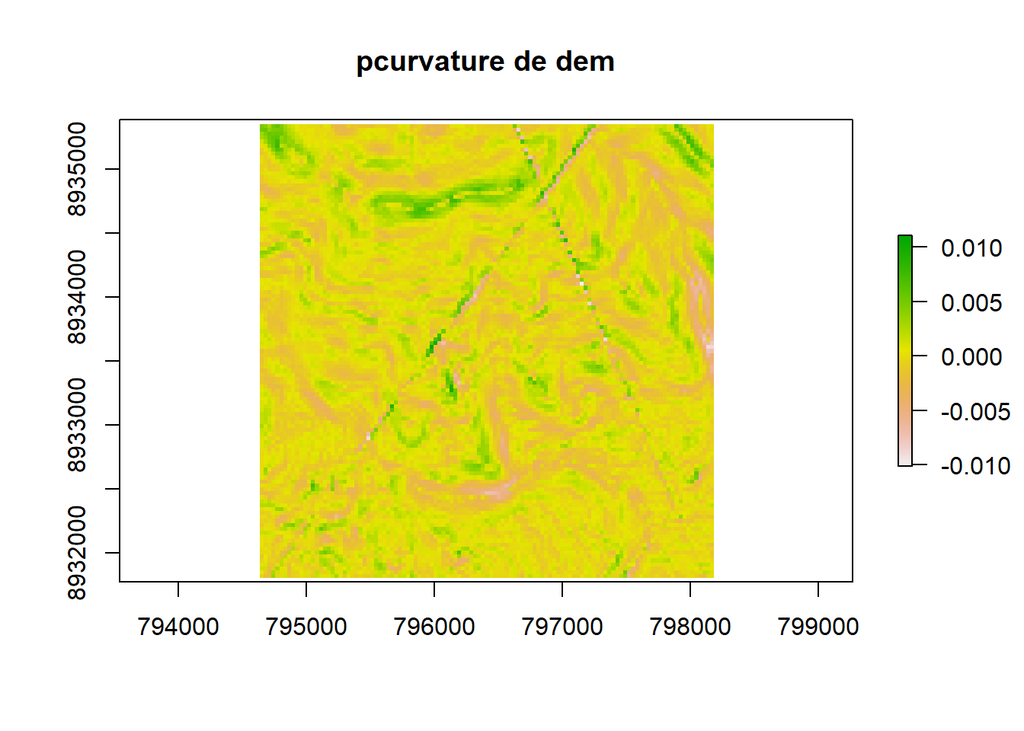

```r
library(raster)
plot(saida[[1]], main = "pcurvature de dem")
```

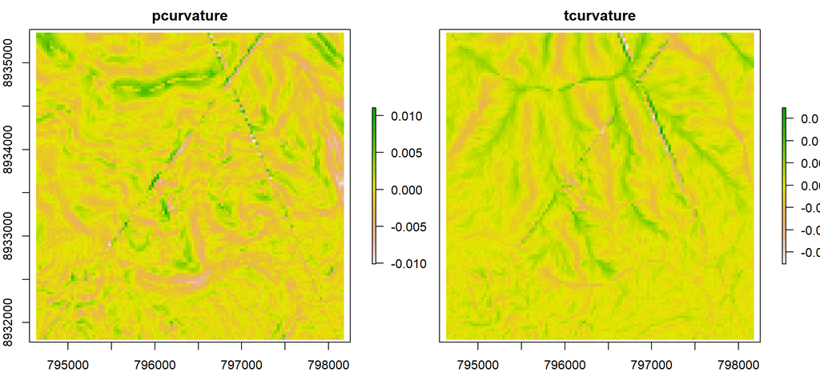

```r
plot(stack(saida))
```